# Analyzing Data from Within-Subjects Designs: Multivariate Approach vs. Linear Mixed Models Approach

## Test effects using different approaches

### Test age effect (between-subjects) via multivariate approach

```r
# c(1, 2, 3) %*% c(-1, 0, 1) means tke the dot product of the matrix c(1, 2, 3) and the matrix c(-1, 0, 1)
# this means multiply 1 by -1, 2 by 0, and 3 by 1, and add up those products
oneway(dv = parse_number(as.matrix(C14T8[, c("Angle0", "Angle4", "Angle8")]) %*% (c(1, 1, 1) / 3)), group = C14T8$Group, contrast = list(age = c(-1, 1)))
```

```
##   contrast   equal_var est       se        t       df          p      lwr
## 1      age     Assumed  94 34.84888 2.697361 18.00000 0.01473401 20.78522
## 2      age Not Assumed  94 34.84888 2.697361 17.78843 0.01483957 20.72275
##        upr
## 1 167.2148
## 2 167.2772
```

### Test angle linear effect (within-subjects)

```r
# c(1, 2, 3) %*% c(-1, 0, 1) means tke the dot product of the matrix c(1, 2, 3) and the matrix c(-1, 0, 1)
# this means multiply 1 by -1, 2 by 0, and 3 by 1, and add up those products
oneway(dv = parse_number(as.matrix(C14T8[, c("Angle0", "Angle4", "Angle8")]) %*% c(-1, 0, 1)), group = C14T8$Group, contrast = list(age = c(1, 1) / 2))
```

```
##   contrast   equal_var   est       se       t       df            p
## 1      age     Assumed 208.5 13.64734 15.2777 18.00000 9.479528e-12
## 2      age Not Assumed 208.5 13.64734 15.2777 17.66239 1.277400e-11
##        lwr      upr
## 1 179.8280 237.1720
## 2 179.7887 237.2113
```

### Test angle quadratic effect (within-subjects)

```r
# c(1, 2, 3) %*% c(-1, 0, 1) means tke the dot product of the matrix c(1, 2, 3) and the matrix c(-1, 0, 1)
# this means multiply 1 by -1, 2 by 0, and 3 by 1, and add up those products
oneway(dv = parse_number(as.matrix(C14T8[, c("Angle0", "Angle4", "Angle8")]) %*% c(1, -2, 1) / 3), group = C14T8$Group, contrast = list(age = c(1, 1) / 2))
```

```
##   contrast   equal_var  est       se         t       df         p
## 1      age     Assumed -3.5 6.220486 -0.562657 18.00000 0.5806094
## 2      age Not Assumed -3.5 6.220486 -0.562657 17.01589 0.5810066
##         lwr      upr
## 1 -16.56876 9.568756
## 2 -16.62314 9.623144
```

### Test angle linear effect x age effect (mixed)

```r
# c(1, 2, 3) %*% c(-1, 0, 1) means tke the dot product of the matrix c(1, 2, 3) and the matrix c(-1, 0, 1)
# this means multiply 1 by -1, 2 by 0, and 3 by 1, and add up those products
oneway(dv = parse_number(as.matrix(C14T8[, c("Angle0", "Angle4", "Angle8")]) %*% c(-1, 0, 1)), group = C14T8$Group, contrast = list(age = c(-1, 1)))
```

```
##   contrast   equal_var est       se       t       df           p      lwr
## 1      age     Assumed  81 27.29469 2.96761 18.00000 0.008245640 23.65599
## 2      age Not Assumed  81 27.29469 2.96761 17.66239 0.008369684 23.57732
##        upr
## 1 138.3440
## 2 138.4227
```

### Test angle quadratic effect x age effect (mixed)

```r
# c(1, 2, 3) %*% c(-1, 0, 1) means tke the dot product of the matrix c(1, 2, 3) and the matrix c(-1, 0, 1)
# this means multiply 1 by -1, 2 by 0, and 3 by 1, and add up those products
oneway(dv = parse_number(as.matrix(C14T8[, c("Angle0", "Angle4", "Angle8")]) %*% c(1, -2, 1) / 3), group = C14T8$Group, contrast = list(age = c(-1, 1)))
```

```
##   contrast   equal_var est       se        t       df          p       lwr
## 1      age     Assumed  25 12.44097 2.009489 18.00000 0.05972078 -1.137512
## 2      age Not Assumed  25 12.44097 2.009489 17.01589 0.06061833 -1.246289
##        upr
## 1 51.13751
## 2 51.24629
```

### Test angle by age effects via linear mixed effects model

```r
# fit model
lmer3 <- lmer(rt ~ (angle_linear + angle_quadratic) * age + (1 + angle_linear + angle_quadratic | subj), data = lC14T8, REML = TRUE, control = lmerControl(check.nobs.vs.nRE = "ignore", check.nobs.vs.nlev = "ignore"))
```

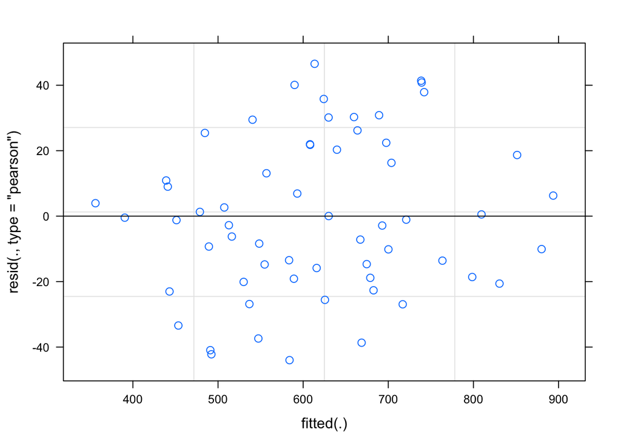

```r
# diagnostics
plot(lmer3)
```

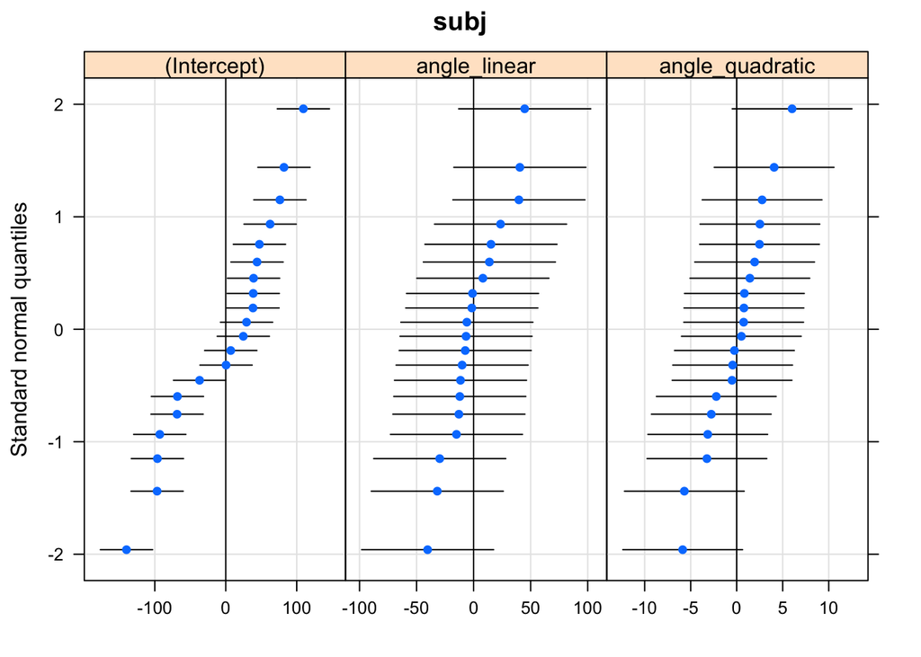

```r
qqmath(ranef(lmer3, condVar = TRUE))
```

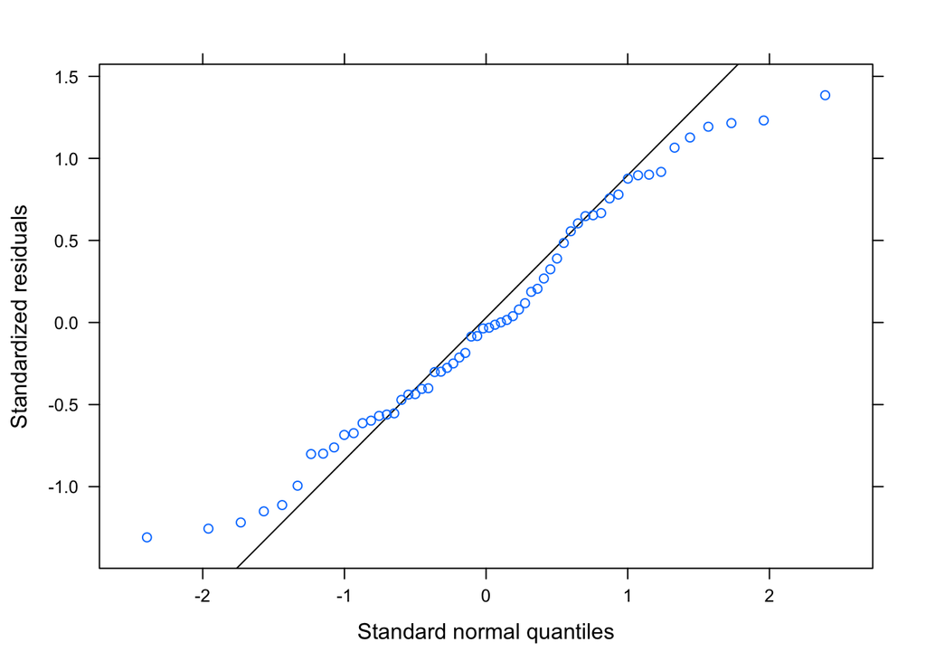

```r
qqmath(lmer3)
```

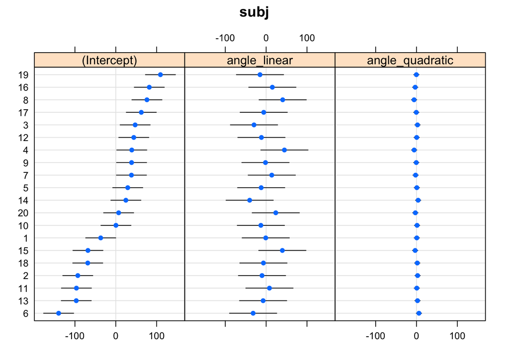

```r
dotplot(ranef(lmer3, condVar = TRUE))
```

```r
# results
summary(lmer2)
```

[output not shown]

# Export data for use in SPSS

```r
write_csv(lC14T8, path = "lC14T8.csv")
```

# Resources

> - Boik, R. J. (1981). A priori tests in repeated measures designs: Effects of nonsphericity. *Psychometrika, 46*(3), 241-255.
> - Maxwell, S. E., Delaney, H. D., & Kelley, K. (2018). *Designing experiments and analyzing data: A model comparison perspective* (3rd ed.). Routledge.
> - [DESIGNING EXPERIMENTS AND ANALYZING DATA](https://designingexperiments.com/) includes computer code for analyses from their book, Shiny apps, and more.

# General word of caution

> Above, I listed resources prepared by experts on these and related topics. Although I generally do my best to write accurate posts, don’t assume my posts are 100% accurate or that they apply to your data or research questions. Trust statistics and methodology experts, not blog posts.